# MRL del volumen de madera en un aserradero

Carol Márquez

29/11/2022

# Modelo de regresión lineal

**Formula:** $y= \beta 0+ \beta 1+ e$

donde:

$y=$ La variable respuesta o dependiente

$x=$ La variable regresora o independiente

$\beta 0 =$ La ordenada al origen

$\beta 1 =$La pendiente

$e =$ El error

## Ejemplo:

# Distribución del volumen de madera en un aserradero

Para el ejemplo se utiliza una base de datos sobre medidas de árboles de los que se obtuvo madera en un aserradero.

**Descripción de las variables**

*HT* = altura en pies. Variable independiente

*DBH* = diámetro del tronco a 4 pies (1.22 metros de altura en pulgadas). Variable independiente

*D16* = diámetro del tronco a 16 pies (4.8768 metros de altura en pulgadas). Variable independiente

*VOL* = volumen de madera obtenida (en pies cúbicos). Variable dependiente

```r
## Librerias

 library(zoo)
 library(xts)
 library(readr)
 library(PerformanceAnalytics)
 library(lmtest)
library(carData)
library(car)
```

```r
Arboles <- read_csv("C:/Users/Carol/Documents/base arboles.csv")
head(Arboles)
```

```
## # A tibble: 6 × 5
##   Árbol   VOL   DBH   D16    HT
##   <dbl> <dbl> <dbl> <dbl> <dbl>
## 1     1  25.9  10.2   9.3  89
## 2     2  45.9  13.7  12.1  90.1
## 3     3  56.2  15.4  13.3  95.1
## 4     4  58.6  14.4  13.4  98.0
## 5     5  63.4  15    14.2  99
## 6     6  46.4  15.0  12.8  91.0
```

```r
Arboles<-Arboles[,-1]
```

**Correlación entre las variables**

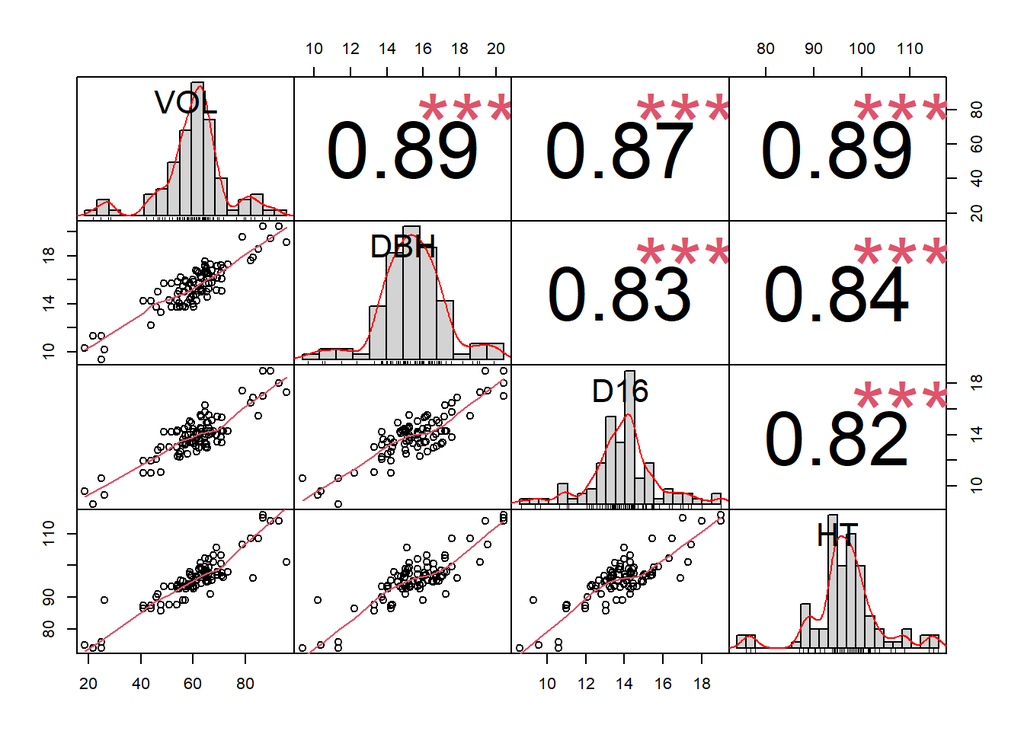

```r
chart.Correlation(Arboles)
```

Se puede observar una alta correlación entre el volumen de madera obtenida con las demás variables. Sin embargo, también hay alta correlación entre las variables, lo que presenta puede presentar problemas de multicolinealidad.

Se procede a realizar la propuesta del modelo.

```r
 ####Ajustar Modelo de regresión lineal

 modelo <- lm(VOL ~ DBH + D16+ HT, data = Arboles)
 modelo
```

```
##
## Call:
## lm(formula = VOL ~ DBH + D16 + HT, data = Arboles)
##
## Coefficients:
## (Intercept)          DBH          D16           HT
##    -72.8193       2.3288       2.1253       0.7116
```

```r
summary(modelo)
```

```
##
## Call:
## lm(formula = VOL ~ DBH + D16 + HT, data = Arboles)
##
## Residuals:
##      Min       1Q   Median       3Q      Max
## -11.6810  -2.8732   0.0253   3.4373  15.3376
##
## Coefficients:
##             Estimate Std. Error t value Pr(>|t|)
## (Intercept) -72.8193     6.9697 -10.448  < 2e-16 ***
## DBH           2.3288     0.4982   4.675 9.61e-06 ***
## D16           2.1253     0.5315   3.998 0.000125 ***
## HT            0.7116     0.1333   5.337 6.29e-07 ***
## ---
## Signif. codes:  0 '***' 0.001 '**' 0.01 '*' 0.05 '.' 0.1 ' ' 1
##
## Residual standard error: 4.773 on 96 degrees of freedom
## Multiple R-squared:  0.8813, Adjusted R-squared:  0.8776
## F-statistic: 237.6 on 3 and 96 DF,  p-value: < 2.2e-16
```

**Planteamiento de Hipótesis:**

$H0$: El modelo No se justa de manera lineal

$Ha$: El modelo se ajusta de manera lineal

El p valor< 0.05. Por lo tanto, se rechaza la H0 y se dice que el modelo si se ajusta de manera líneal a los datos.

El valor de R cuadrado: 0.8776, nos dice que de la variabilidad total del volumen de madera obtenida de los árboles, el 87.76% esta explicada por la altura, el diámetro del tronco a 4 pies y el diámetro del tronco a 16 pies.

*Análisis de varianza*

```r
anova<-anova(modelo)
anova
```

```
## Analysis of Variance Table
##
## Response: VOL
##           Df  Sum Sq Mean Sq F value    Pr(>F)
## DBH        1 14491.1 14491.1 635.978 < 2.2e-16 ***
## D16        1  1100.4  1100.4  48.295 4.405e-10 ***
## HT         1   649.1   649.1  28.488 6.295e-07 ***
## Residuals 96  2187.4    22.8
## ---
## Signif. codes:  0 '***' 0.001 '**' 0.01 '*' 0.05 '.' 0.1 ' ' 1
```

Se observa que todas las variables son significativas.

*Intervalos de confianza*

Se muestran los intervalos a un 95% de confianza.

```r
confint(modelo, level=0.95)
```

```
##                   2.5 %      97.5 %
## (Intercept) -86.6540816 -58.9845592
## DBH           1.3399099   3.3176013
## D16           1.0702072   3.1803298
## HT            0.4469791   0.9762974
```

# Validación de los supuestos

*Normalidad*

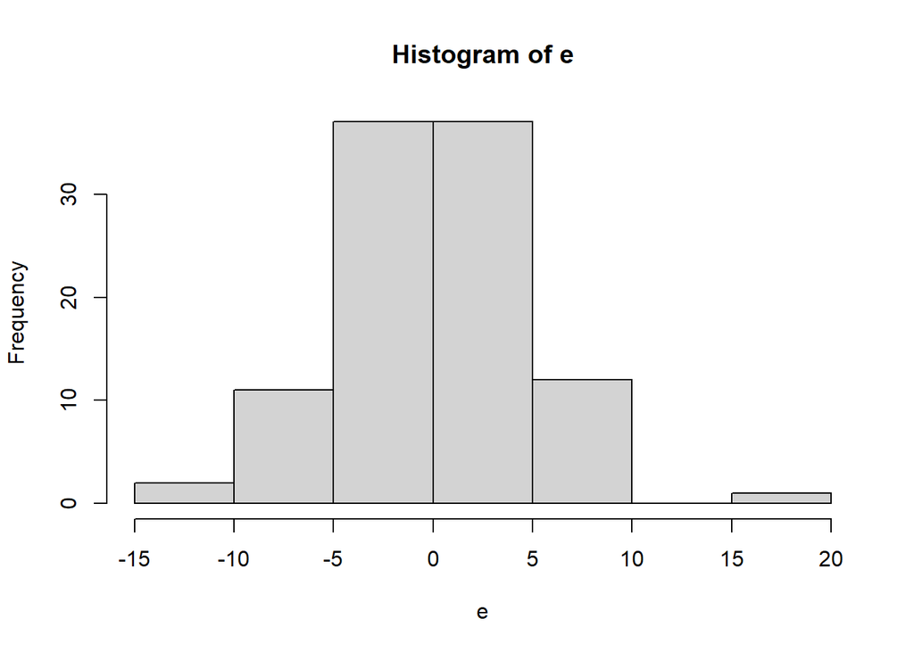

```r
##Histograma de los residuales
e<-modelo$residuals
hist(e)
```

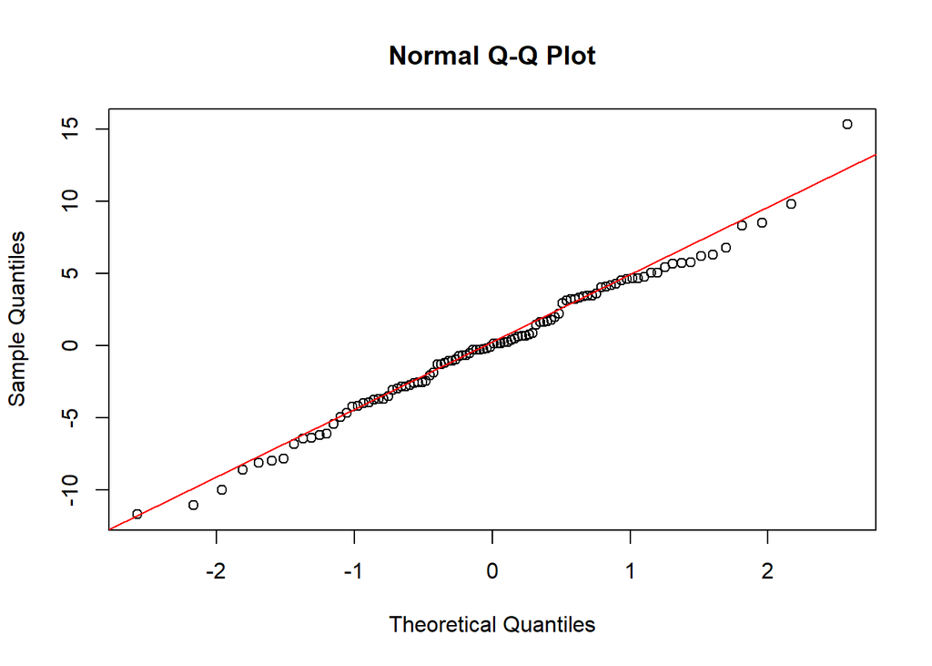

```r
qqnorm(e)
qqline(e, col="red")
```

Planteamiento de Hipótesis:

$h0$: Los errores se distribuyen de manera normal.

$h1$: Los errores no se distribuyen de manera normal.

```r
##Test de Shapiro Wilk para probar normalidad

shapiro.test(e)
```

```
##
##  Shapiro-Wilk normality test
##
## data:  e
## W = 0.98964, p-value = 0.6356
```

**Homogeneidad de varianza**

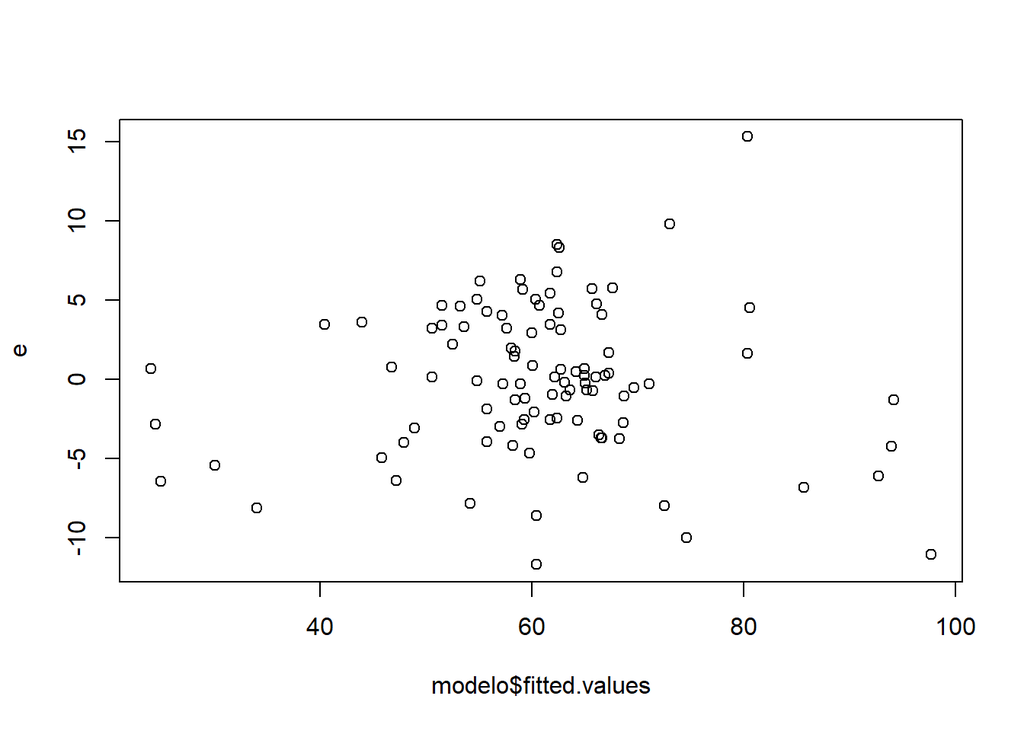

```r
plot(e~modelo$fitted.values)
```

```r
##prueba de Breush pagan
bptest(modelo)
```

```
##
##  studentized Breusch-Pagan test
##
## data:  modelo
## BP = 10.346, df = 3, p-value = 0.01584
```

Planteamiento de hipótesis

$h0$: Existe homogeneidad de varianza

$h1$: No existe homogeneidad de varianza

**Independencia**

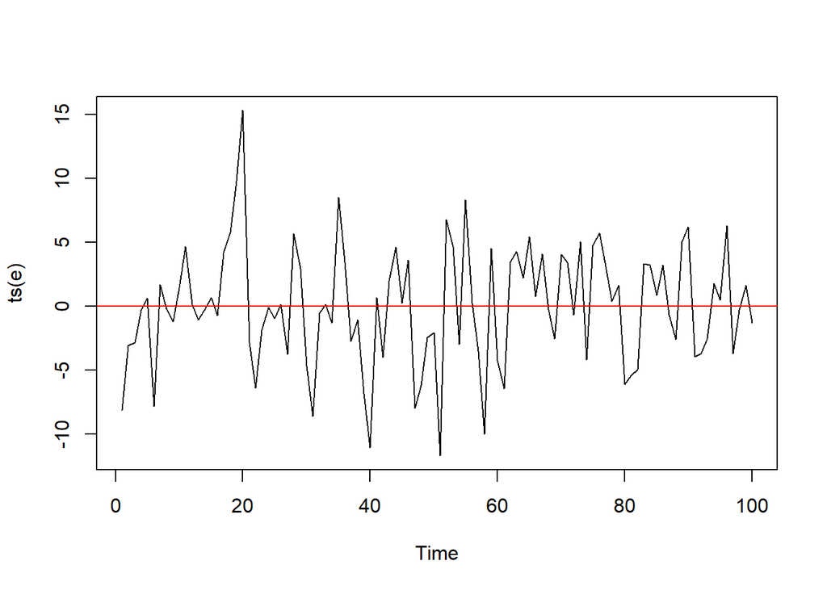

```r
plot(ts(e))
abline(h=0, col="red")
```

Planteamiento de hipótesis:

$ho$: No hay autocorrelación entre los errores o son independientes.

$ha$: Hay autocorrelación entre los errores o NO son independientes.

Prueba de Durbin Watson para probar independencia

```r
dwt(modelo, alternative ="two.sided")
```

```
##  lag Autocorrelation D-W Statistic p-value
##    1       0.1807207      1.607747   0.038
##  Alternative hypothesis: rho != 0
```

# Conclusión